# CSC4020 HW3 Programming

### @117020119 Jiang Jingxin

## Multi-class Classification for MNIST

```python
import numpy as np
import matplotlib.pyplot as plt
np.random.seed(42)
```

## 0. MNIST Dataset

### 0.1 Data loader

```python
import pickle as pk
import gzip
def load_data():
    f = gzip.open('mnist.pkl.gz', 'rb')
    training_data, validation_data, test_data = pk.load(f,encoding='bytes')
    f.close()
    return (training_data , validation_data , test_data)
```

### 0.2 MNIST data

```python
training_data , validation_data , test_data = load_data()
```

## 1. Fully Connected NN

### 1.1 Dense layer

```python
class Dense():
    def __init__(self, in_dim, out_dim, activation):
        self.w = np.random.normal(loc=0.0,
                                  scale = np.sqrt(2/(in_dim+out_dim)),
                                  size = (in_dim, out_dim))
        self.b= np.zeros(out_dim)
        self.activation = activation

    def _activate(self, x):
        if self.activation == 'sigmoid':
            return 1/(1+np.exp(-x))
        if self.activation == 'tanh':
            return np.tanh(x)
        if self.activation == 'relu':
            return np.maximum(0,x)
        return x

    def _gradient(self,x):
        if self.activation == 'sigmoid':
            x = self._activate(x)
            return x*(1-x)
        if self.activation == 'tanh':
            x = self._activate(x)
            return 1-x**2
        if self.activation == 'relu':
            x = self._activate(x)
            return np.sign(x)
        return np.ones_like(x)

    def forward(self,inp):
        return self._activate(np.dot(inp,self.w) + self.b)

    def backward(self,inp,grad_out,lr,regularization,lmbd):
        delta = self._gradient(inp@self.w)*grad_out
        grad_inp = delta@self.w.T
        if regularization == 'L2':
            self.w -= lr * lmbd / len(inp) * self.w
        elif regularization == 'L1':
            self.w -= lr * lmbd / len(inp) * np.sign(self.w)
        self.w = self.w - lr/ len(inp) * inp.T@delta
        self.b = self.b - lr/ len(inp) * delta.mean(axis=0)*inp.shape[0]

        return grad_inp
```

### 1.2 Neural Network

```python
class NeuralNetwork:
    def __init__(self):
        self._layer = list()

    def add_layer(self, in_dim, out_dim, activation):
        self._layer.append(Dense(in_dim, out_dim, activation))

    def _loss(self,logit,y):
        if self.cost == 'CrossEntropy':
            fx = logit[np.arange(len(logit)),y]
            return np.mean(np.log(np.sum(np.exp(logit),axis=-1))-fx)
        if self.cost == 'MSE':
            enc = np.zeros_like(logit)
            enc[np.arange(len(logit)),y] = 1
            softmax = np.exp(logit) / np.exp(logit).sum(axis=1,keepdims=True)
            return np.mean((softmax-enc)**2)

    def _grad(self,logit,y):
        if self.cost == 'CrossEntropy':
            enc = np.zeros_like(logit)
            enc[np.arange(len(logit)),y] = 1
            softmax = np.exp(logit)/ np.exp(logit).sum(axis=-1,keepdims=True)
            return (- enc + softmax) / logit.shape[0]
        if self.cost == 'MSE':
            fx = np.vstack(logit[np.arange(len(logit)),y])
            enc = np.zeros_like(logit)
            enc[np.arange(len(logit)),y] = 1
            softmax = np.exp(logit) / np.exp(logit).sum(axis=1,keepdims=True)
            return (softmax**2 - softmax*(enc-fx+softmax.sum(axis=1,keepdims=True)))*2/logit.size

    def _feedfwd(self,X):
        layer_inp = []
        inp = X
        for layer in self._layer:
            layer_inp.append(inp)
            inp = layer.forward(inp)
        return layer_inp, inp

    def _bwdprop(self, layer_inp, grad_out):
        l = len(self._layer)-1
        while l>=0:
            layer = self._layer[l]
            grad_out = layer.backward(layer_inp[l],grad_out,self.lr,self.regularization,self.lmbd)
            l -= 1

    def _iter_batch(self, X, y, batch):
        from tqdm import trange
        indices = np.random.permutation(len(X))
        for i in trange(0, len(X) - batch + 1, batch):
            index = indices[i:i + batch]
            yield X[index], y[index]

    def _train(self,X,y):
        layer_inp, logit = self._feedfwd(X)
        grad_out = self._grad(logit,y)
        self._bwdprop(layer_inp,grad_out)
        return (self._loss(logit,y))

    def fit(self,X_train,y_train,X_valid,y_valid,epoch,batch,lr,cost,regularization=None,lmbd=0,show=False):
        from IPython.display import display, clear_output

        self.lr = lr
        self.cost = cost
        self.regularization = regularization
        self.lmbd = lmbd

        train_log = []
        valid_log = []
        for i in range(epoch):
            for x_batch,y_batch in self._iter_batch(X_train,y_train,batch):
                self._train(x_batch,y_batch)
            train_log.append(np.mean(self.predict(X_train)==y_train))
            valid_log.append(np.mean(self.predict(X_valid)==y_valid))
            clear_output(wait=True)
            display("Epoch:"+str(i+1)+", "+\
                    "Train accuracy:"+str(train_log[-1])+", "+\
                    "Valid accuracy:"+str(valid_log[-1]))
            if show:
                plt.plot(train_log,label='train accuracy')
                plt.plot(valid_log,label='valid accuracy',linestyle='--')
                plt.legend(loc='best')
                plt.grid()
                plt.show()

        return {'train':train_log, 'valid':valid_log}

    def predict(self,X):
        logit = self._feedfwd(X)[-1]
        return logit.argmax(axis=-1)
```

## 2. Experiment

### 2.0 Default config

1. *number of hidden layers*: **2**
2. *activation functions*: **relu**
3. *hidden nodes in each hidden layer*: **100+100**
4. *learning rate*: **3**
5. *epochs*: **30**
6. *minibatch size*: **50**
7. *cost*: **CrossEntropy**
8. *regularization*: **None**

```
'Epoch:30, Train accuracy:0.99988, Valid accuracy:0.9773'
```

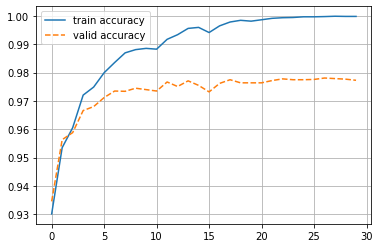

```python
np.random.seed(42)
defaultNN = NeuralNetwork()
defaultNN.add_layer(784,100,'relu')
defaultNN.add_layer(100,100,'relu')
defaultNN.add_layer(100,10,'linear')
default_log = defaultNN.fit(training_data[0],training_data[1],
                            validation_data[0], validation_data[1],
                            epoch = 30, batch = 50,lr=3,
                            cost='CrossEntropy',
                            show=True)
```

### 2.1 Number of hidden layers

#### 2.1.1 *number of hidden layers* = **1**

```python
np.random.seed(42)
configNN1_1 = NeuralNetwork()
configNN1_1.add_layer(784,100,'relu')
configNN1_1.add_layer(100,10,'linear')
config1_1_log = configNN1_1.fit(training_data[0],training_data[1],
                                validation_data[0], validation_data[1],
                                epoch = 30, batch = 50,lr=3,
                                cost='CrossEntropy')
```

```
'Epoch:30, Train accuracy:0.99616, Valid accuracy:0.9762'
```

#### 2.1.2 *number of hidden layers* = **2** → <2.0 Default config>

#### 2.1.3 *accuracy vs epoch plot*

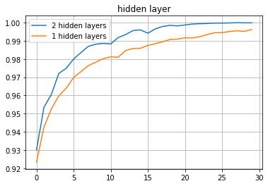

```python
plt.plot(default_log["train"],label='2 hidden layers')
plt.plot(config1_1_log["train"],label='1 hidden layers')
plt.legend(loc='best')
plt.title('hidden layer')
plt.grid()
plt.show()
```

#### 2.1.4 *result analysis*

Since the 2 hidden layer network is more flexible, it outperforms 1 hidden layer network.

However, it seems that 1 hidden layer network is flexible enough to fit the data.

### 2.2 Activation functions

#### 2.2.1 *activation functions* = **sigmod**

```python
np.random.seed(42)
configNN2_1 = NeuralNetwork()
configNN2_1.add_layer(784,100,'sigmod')
configNN2_1.add_layer(100,100,'sigmod')
configNN2_1.add_layer(100,10,'linear')
config2_1_log = configNN2_1.fit(training_data[0],training_data[1],
                                validation_data[0], validation_data[1],
                                epoch = 30, batch = 50,lr=3,
                                cost='CrossEntropy')
```

```
'Epoch:30, Train accuracy:0.92838, Valid accuracy:0.9253'
```

#### 2.2.2 *activation functions* = **tanh**

```python
np.random.seed(42)
configNN2_2 = NeuralNetwork()
configNN2_2.add_layer(784,100,'tanh')
configNN2_2.add_layer(100,100,'tanh')
configNN2_2.add_layer(100,10,'linear')
config2_2_log = configNN2_2.fit(training_data[0],training_data[1],
                                validation_data[0], validation_data[1],
                                epoch = 30, batch = 50,lr=3,
                                cost='CrossEntropy')
```

```
'Epoch:30, Train accuracy:0.9995, Valid accuracy:0.9792'
```

#### 2.2.3 *activation functions* = **relu** → <2.0 Default config>

#### 2.2.4 *accuracy vs epoch plot*

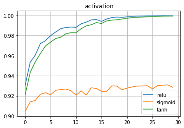

```python
plt.plot(default_log["train"],label='relu')
plt.plot(config2_1_log["train"],label='sigmoid')
plt.plot(config2_2_log["train"],label='tanh')
plt.legend(loc='best')
plt.title('activation')
plt.grid()
plt.show()
```

#### 2.2.5 *result analysis*

The tanh activation has similar performance with relu activation, but converges slightly slower.

### 2.3 Hidden nodes in each hidden layer

#### 2.3.1 *hidden nodes in each hidden layer* = **50+50**

```python
np.random.seed(42)
configNN3_1 = NeuralNetwork()
configNN3_1.add_layer(784,50,'relu')
configNN3_1.add_layer(50,50,'relu')
configNN3_1.add_layer(50,10,'linear')
config3_1_log = configNN3_1.fit(training_data[0],training_data[1],
                                        validation_data[0], validation_data[1],
                                        epoch = 30, batch = 50,lr=3,
                                        cost='CrossEntropy')
```

```
'Epoch:30, Train accuracy:0.99856, Valid accuracy:0.9726'
```

#### 2.3.2 *hidden nodes in each hidden layer* = **50+100**

```python
np.random.seed(42)
configNN3_2 = NeuralNetwork()
configNN3_2.add_layer(784,50,'relu')
configNN3_2.add_layer(50,100,'relu')
configNN3_2.add_layer(100,10,'linear')
config3_2_log = configNN3_2.fit(training_data[0],training_data[1],
                                validation_data[0], validation_data[1],
                                epoch = 30, batch = 50,lr=3,
                                cost='CrossEntropy')
```

```
'Epoch:30, Train accuracy:0.99896, Valid accuracy:0.9757'
```

#### 2.3.3 *hidden nodes in each hidden layer* = **100+50**

```python
np.random.seed(42)
configNN3_3 = NeuralNetwork()
configNN3_3.add_layer(784,100,'relu')
configNN3_3.add_layer(100,50,'relu')
configNN3_3.add_layer(50,10,'linear')
config3_3_log = configNN3_3.fit(training_data[0],training_data[1],
                                validation_data[0], validation_data[1],
                                epoch = 30, batch = 50,lr=3,
                                cost='CrossEntropy')
```

```
'Epoch:30, Train accuracy:0.99956, Valid accuracy:0.9774'
```

#### 2.3.4 *hidden nodes in each hidden layer* = **100+100** → <2.0 Default config>

#### 2.3.5 *accuracy vs epoch plot*

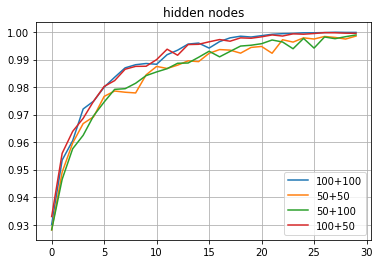

```python
plt.plot(default_log["train"],label='100+100')
plt.plot(config3_1_log["train"],label='50+50')
plt.plot(config3_2_log["train"],label='50+100')
plt.plot(config3_3_log["train"],label='100+50')
plt.legend(loc='best')
plt.title('hidden nodes')
plt.grid()
plt.show()
```

#### 2.3.6 *result analysis*

It seems that, the converge speech is more dependent on the number of nodes in the first hidden layer.

The number of nodes in the second layer won't affect the converge speech much.

A proper decrease in the number of nodes in the second layer is favorable when the dataset is large to reduce computations.

### 2.4 Learning rate

#### 2.4.1 *learning rate* = **0.001**

```python
np.random.seed(42)
configNN4_1 = NeuralNetwork()
configNN4_1.add_layer(784,100,'relu')
configNN4_1.add_layer(100,100,'relu')
configNN4_1.add_layer(100,10,'linear')
config4_1_log = configNN4_1.fit(training_data[0],training_data[1],
                                validation_data[0], validation_data[1],
                                epoch = 30, batch = 50,lr=0.001,
                                cost='CrossEntropy')
```

```
'Epoch:30, Train accuracy:0.35294, Valid accuracy:0.3656'
```

#### 2.4.2 *learning rate* = **0.01**

```python
np.random.seed(42)
configNN4_2 = NeuralNetwork()
configNN4_2.add_layer(784,100,'relu')
configNN4_2.add_layer(100,100,'relu')
configNN4_2.add_layer(100,10,'linear')
config4_2_log = configNN4_2.fit(training_data[0],training_data[1],
                                validation_data[0], validation_data[1],
                                epoch = 30, batch = 50,lr=0.01,
                                cost='CrossEntropy')
```

```
'Epoch:30, Train accuracy:0.85114, Valid accuracy:0.8709'
```

#### 2.4.3 *learning rate* = **0.1**

```python
np.random.seed(100)
configNN4_4 = NeuralNetwork()
configNN4_4.add_layer(784,100,'relu')
configNN4_4.add_layer(100,100,'relu')
configNN4_4.add_layer(100,10,'linear')
config4_4_log = configNN4_4.fit(training_data[0],training_data[1],
                                validation_data[0], validation_data[1],
                                epoch = 30, batch = 50,lr=0.1,
                                cost='CrossEntropy')
```

```
'Epoch:30, Train accuracy:0.93692, Valid accuracy:0.9427'
```

#### 2.4.4 *learning rate* = **1**

```python
np.random.seed(100)
configNN4_3 = NeuralNetwork()
configNN4_3.add_layer(784,100,'relu')
configNN4_3.add_layer(100,100,'relu')
configNN4_3.add_layer(100,10,'linear')
config4_3_log = configNN4_3.fit(training_data[0],training_data[1],
                                validation_data[0], validation_data[1],
                                epoch = 30, batch = 50,lr=1,
                                cost='CrossEntropy')
```

```
'Epoch:30, Train accuracy:0.99312, Valid accuracy:0.9744'
```

#### 2.4.4 *learning rate* = **3** → <2.0 Default config>

#### 2.4.5 *accuracy vs epoch plot*

[figure not shown]

```python
plt.plot(config4_1_log["train"],label='0.001')
plt.plot(config4_2_log["train"],label='0.01')
plt.plot(config4_3_log["train"],label='0.1')
plt.plot(config4_4_log["train"],label='1')
plt.plot(default_log["train"],label='3')
plt.legend(loc='best')
plt.title('learning rate')
plt.grid()
plt.show()
```

#### 2.4.6 *result analysis*

As the learning rate increase from 0.001 to 3, the training speed is increasing, and the model converges faster.

If the learning rate is too small, it will take forever to fit the data.

### 2.5 Epochs

#### 2.5.1 *epochs* = **30** → <2.0 Default config>

#### 2.5.2 *epochs* = **100**

```python
np.random.seed(42)
configNN5 = NeuralNetwork()
configNN5.add_layer(784,100,'relu')
configNN5.add_layer(100,100,'relu')
configNN5.add_layer(100,10,'linear')
config5_log = configNN5.fit(training_data[0],training_data[1],
                            validation_data[0], validation_data[1],
                            epoch = 100, batch = 50,lr=3,
                            cost='CrossEntropy')
```

```
'Epoch:100, Train accuracy:1.0, Valid accuracy:0.9779'
```

#### 2.5.3 *accuracy vs epoch plot*

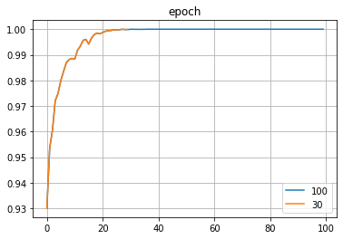

```python
plt.plot(config5_log["train"],label='100')
plt.plot(default_log["train"],label='30')
plt.legend(loc='best')
plt.title('epoch')
plt.grid()
plt.show()
```

#### 2.5.4 *result analysis*

Too many epochs may not be that necessary when the model has already achieved a decent accuracy in small epochs.

There is a diminising marginal accuracy gain when the more epochs get trained.